# Analysis on Sustainable Development Goals (SDGs) Indicators

## by Mostafa Teleb

## Historical preview

##### -In June 1992, at the Earth Summit in Rio de Janeiro, Brazil, more than 178 countries adopted Agenda 21, a comprehensive plan of action to build a global partnership for sustainable development to improve human lives and protect the environment.

##### -Member States unanimously adopted the Millennium Declaration at the Millennium Summit in September 2000 at UN Headquarters in New York. The Summit led to the elaboration of eight Millennium Development Goals (MDGs) to reduce extreme poverty by 2015.

##### -The Johannesburg Declaration on Sustainable Development and the Plan of Implementation, adopted at the World Summit on Sustainable Development in South Africa in 2002, reaffirmed the global community's commitments to poverty eradication and the environment, and built on Agenda 21 and the Millennium Declaration by including more emphasis on multilateral partnerships.

##### -At the United Nations Conference on Sustainable Development (Rio+20) in Rio de Janeiro, Brazil, in June 2012, Member States adopted the outcome document "The Future We Want" in which they decided, inter alia, to launch a process to develop a set of SDGs to build upon the MDGs and to establish the UN High-level Political Forum on Sustainable Development. The Rio +20 outcome also contained other measures for implementing sustainable development, including mandates for future programmes of work in development financing, small island developing states and more.

##### -In 2013, the General Assembly set up a 30-member Open Working Group to develop a proposal on the SDGs.

##### -In January 2015, the General Assembly began the negotiation process on the post-2015 development agenda. The process culminated in the subsequent adoption of the 2030 Agenda for Sustainable Development, with 17 SDGs at its core, at the UN Sustainable Development Summit in September 2015.

##### -2015 was a landmark year for multilateralism and international policy shaping, with the adoption of several major agreements:

###### 1- Sendai Framework for Disaster Risk Reduction (March 2015)

###### 2- Addis Ababa Action Agenda on Financing for Development (July 2015)

###### 3-Transforming our world: the 2030 Agenda for Sustainable Development with its 17 SDGs was adopted at the UN Sustainable Development Summit in New York in September 2015.

###### 4- Paris Agreement on Climate Change (December 2015)

##### -Now, the annual High-level Political Forum on Sustainable Development serves as the central UN platform for the follow-up and review of the SDGs.

## In General

### SDG indicators: The Sustainable Development Goals (SDGs) are a collection of 17 goals designed to monitor progress to various sustainability targets defined by the United Nations 2030 agenda (No Poverty, Clean water and sanitation, Sustainable cities and communities, Climate Action…).

### so we collecting the indicators from separated sources and cleanning them and after that we do Exploratory Data Analysis (EDA) on the (indicators) and make some Visualization

## collecting the indicators and clean each of them

## first indicator

```python
df=pd.read_csv('country-level-government-spending-vs-income.csv')
print(df.shape)
df.head()
```

```
(57074, 7)
```

|  | Entity | Code | Year | Government Expenditure (IMF based on Mauro et al. (2015)) | GDP per capita, PPP (constant 2017 international $) | Population (historical estimates) | Continent |
| --- | --- | --- | --- | --- | --- | --- | --- |
| 0 | Abkhazia | OWID_ABK | 2015 | NaN | NaN | NaN | Asia |
| 1 | Afghanistan | AFG | 2003 | 14.066129 | 1235.810063 | 23680871.0 | NaN |
| 2 | Afghanistan | AFG | 2004 | 15.657322 | 1200.278013 | 24726689.0 | NaN |
| 3 | Afghanistan | AFG | 2005 | 17.206297 | 1286.793659 | 25654274.0 | NaN |
| 4 | Afghanistan | AFG | 2006 | 21.535529 | 1315.789117 | 26433058.0 | NaN |

```python
df.drop(['Continent'],axis=1,inplace=True)
df=df.dropna()
print(df.shape)
df.head()
```

```
(2930, 6)
```

|  | Entity | Code | Year | Government Expenditure (IMF based on Mauro et al. (2015)) | GDP per capita, PPP (constant 2017 international $) | Population (historical estimates) |
| --- | --- | --- | --- | --- | --- | --- |
| 1 | Afghanistan | AFG | 2003 | 14.066129 | 1235.810063 | 23680871.0 |
| 2 | Afghanistan | AFG | 2004 | 15.657322 | 1200.278013 | 24726689.0 |
| 3 | Afghanistan | AFG | 2005 | 17.206297 | 1286.793659 | 25654274.0 |
| 4 | Afghanistan | AFG | 2006 | 21.535529 | 1315.789117 | 26433058.0 |
| 5 | Afghanistan | AFG | 2007 | 21.991904 | 1460.825751 | 27100542.0 |

```python
with open('New folder\country-level-government-spending-vs-income.csv', 'w', newline='') as f:
    writer = csv.writer(f)
    writer.writerow(['country_name','country_code','Government Expenditure (IMF based on Mauro et al. (2015))','GDP per capita, PPP (constant 2017 international $)'])
    for i in range(len(df)):
        year=int(str(df.iloc[[i],[2]]).split(' ')[-1])
        if year == 2007:
            country=''.join(str(df.iloc[[i],[0]]).split(' ')[-2:])
            code=str(df.iloc[[i],[1]]).split(' ')[-1]
            population=float(''.join(str(df.iloc[[i],[3]]).split(' ')[-9:]))
            z=float(str(df.iloc[[i],[4]]).split(' ')[-3])
            writer.writerow([country,code,population,z])
```

## scond indicator

```python
df=pd.read_csv('arable-land-use-per-person.csv')
print(df.shape)
df.head()
```

```
(13592, 4)
```

|  | Entity | Code | Year | Arable land (hectares per person) |
| --- | --- | --- | --- | --- |
| 0 | Afghanistan | AFG | 1961 | 0.834296 |
| 1 | Afghanistan | AFG | 1962 | 0.823402 |
| 2 | Afghanistan | AFG | 1963 | 0.812097 |
| 3 | Afghanistan | AFG | 1964 | 0.800429 |
| 4 | Afghanistan | AFG | 1965 | 0.783422 |

```python
df.drop(['Code'],axis=1,inplace=True)
df=df.dropna()
print(df.shape)
df.head()
```

```
(13592, 3)
```

|  | Entity | Year | Arable land (hectares per person) |
| --- | --- | --- | --- |
| 0 | Afghanistan | 1961 | 0.834296 |
| 1 | Afghanistan | 1962 | 0.823402 |
| 2 | Afghanistan | 1963 | 0.812097 |
| 3 | Afghanistan | 1964 | 0.800429 |
| 4 | Afghanistan | 1965 | 0.783422 |

```python
with open('New folder\Arable-land-use-per-person.csv', 'w', newline='') as f:
    writer = csv.writer(f)
    writer.writerow(['country_name','Arable land (hectares per person)'])
    for i in range(len(df)):
        year=int(str(df.iloc[[i],[1]]).split(' ')[-1])
        if year == 2017:
            country=''.join(str(df.iloc[[i],[0]]).split(' ')[-2:])
          #  population=float(''.join(str(df.iloc[[i],[2]]).split(' ')[-9:]))
            z=float(str(df.iloc[[i],[2]]).split(' ')[-1])
            writer.writerow([country,z])
```

### Third indicator

```python
df=pd.read_csv('correlation-between-oecd-pisa-reading-test-score-and-un-human-development-index-2012.csv')
print(df.shape)
df.head()
```

```
(55729, 7)
```

|  | Entity | Code | Year | PISA: Mean performance on the reading scale | Human Development Index - undp_hdi | Continent | Population (historical estimates) |
| --- | --- | --- | --- | --- | --- | --- | --- |
| 0 | Abkhazia | OWID_ABK | 2015 | NaN | NaN | Asia | NaN |
| 1 | Afghanistan | AFG | 1990 | NaN | 0.296681 | NaN | 12412311.0 |
| 2 | Afghanistan | AFG | 2000 | NaN | 0.334263 | NaN | 20779957.0 |
| 3 | Afghanistan | AFG | 2010 | NaN | 0.447722 | NaN | 29185511.0 |
| 4 | Afghanistan | AFG | 2011 | NaN | 0.455618 | NaN | 30117411.0 |

```python
df.drop(['Code','Continent','PISA: Mean performance on the reading scale'],axis=1,inplace=True)
df=df.dropna()
print(df.shape)
df.head()
```

```
(1193, 4)
```

|  | Entity | Year | Human Development Index - undp_hdi | Population (historical estimates) |
| --- | --- | --- | --- | --- |
| 1 | Afghanistan | 1990 | 0.296681 | 12412311.0 |
| 2 | Afghanistan | 2000 | 0.334263 | 20779957.0 |
| 3 | Afghanistan | 2010 | 0.447722 | 29185511.0 |
| 4 | Afghanistan | 2011 | 0.455618 | 30117411.0 |
| 5 | Afghanistan | 2012 | 0.463019 | 31161378.0 |

```python
with open('New folder\human Development Index.csv', 'w', newline='') as f:
    writer = csv.writer(f)
    writer.writerow(['country_name','Human Development Index - undp_hdi','Population (historical estimates)'])
    for i in range(len(df)):
        year=int(str(df.iloc[[i],[1]]).split(' ')[-1])
        if year == 2010:
            country=''.join(str(df.iloc[[i],[0]]).split(' ')[-2:])
            y=float(str(df.iloc[[i],[3]]).split(' ')[-1])
            z=float(str(df.iloc[[i],[2]]).split(' ')[-1])
            writer.writerow([country,z,y])
        else:
            pass
```

### fourth indicator

```python
df=pd.read_csv('death-rates-unsafe-water.csv')
print(df.shape)
df.head()
```

```
(6468, 4)
```

|  | Entity | Code | Year | Deaths - Unsafe water source - Sex: Both - Age: Age-standardized (Rate) |
| --- | --- | --- | --- | --- |
| 0 | Afghanistan | AFG | 1990 | 45.079901 |
| 1 | Afghanistan | AFG | 1991 | 40.391004 |
| 2 | Afghanistan | AFG | 1992 | 31.672732 |
| 3 | Afghanistan | AFG | 1993 | 33.811224 |
| 4 | Afghanistan | AFG | 1994 | 34.499943 |

```python
df.drop(['Code'],axis=1,inplace=True)
df=df.dropna()
print(df.shape)
df.head()
```

```
(6468, 3)
```

|  | Entity | Year | Deaths - Unsafe water source - Sex: Both - Age: Age-standardized (Rate) |
| --- | --- | --- | --- |
| 0 | Afghanistan | 1990 | 45.079901 |
| 1 | Afghanistan | 1991 | 40.391004 |
| 2 | Afghanistan | 1992 | 31.672732 |
| 3 | Afghanistan | 1993 | 33.811224 |
| 4 | Afghanistan | 1994 | 34.499943 |

```python
with open('New folder\Deaths - Unsafe water source.csv', 'w', newline='') as f:
    writer = csv.writer(f)
    writer.writerow(['country_name','Deaths - Unsafe water source'])
    for i in range(len(df)):
        year=int(str(df.iloc[[i],[1]]).split(' ')[-1])
        if year == 2017:
            country=''.join(str(df.iloc[[i],[0]]).split(' ')[-2:])
            #y=float(str(df.iloc[[i],[3]]).split(' ')[-1])
            z=float(''.join(str(df.iloc[[i],[2]]).split(' ')[-23:]))
            writer.writerow([country,z])
        else:
            pass
```

### fifth ind.

```python
df=pd.read_csv('gender-wage-gap-vs-gdp-per-capita.csv')
print(df.shape)
df.head()
```

```
(57131, 7)
```

|  | Entity | Code | Year | Gender wage gap (%) | GDP per capita, PPP (current international $) | Population (historical estimates) | Continent |
| --- | --- | --- | --- | --- | --- | --- | --- |
| 0 | Abkhazia | OWID_ABK | 2015 | NaN | NaN | NaN | Asia |
| 1 | Afghanistan | AFG | 2002 | NaN | 877.014268 | 22600774.0 | NaN |
| 2 | Afghanistan | AFG | 2003 | NaN | 927.857548 | 23680871.0 | NaN |
| 3 | Afghanistan | AFG | 2004 | NaN | 925.441429 | 24726689.0 | NaN |
| 4 | Afghanistan | AFG | 2005 | NaN | 1023.051749 | 25654274.0 | NaN |

```python
df.drop(['Code','Continent','GDP per capita, PPP (current international $)'],axis=1,inplace=True)
df.info()
df=df.fillna(0)
print(df.shape)
df.head()
```

```
<class 'pandas.core.frame.DataFrame'>
RangeIndex: 57131 entries, 0 to 57130
Data columns (total 4 columns):
 #   Column                             Non-Null Count  Dtype
---  ------                             --------------  -----
 0   Entity                             57131 non-null  object
 1   Year                               57131 non-null  int64
 2   Gender wage gap (%)                413 non-null    float64
 3   Population (historical estimates)  55656 non-null  float64
dtypes: float64(2), int64(1), object(1)
memory usage: 1.7+ MB
(57131, 4)
```

|  | Entity | Year | Gender wage gap (%) | Population (historical estimates) |
| --- | --- | --- | --- | --- |
| 0 | Abkhazia | 2015 | 0.0 | 0.0 |
| 1 | Afghanistan | 2002 | 0.0 | 22600774.0 |
| 2 | Afghanistan | 2003 | 0.0 | 23680871.0 |
| 3 | Afghanistan | 2004 | 0.0 | 24726689.0 |
| 4 | Afghanistan | 2005 | 0.0 | 25654274.0 |

```python
with open('New folder\Gender wage gap.csv', 'w', newline='') as f:
    writer = csv.writer(f)
    writer.writerow(['country_name','Gender wage gap (%)','Population'])
    for i in range(len(df)):
        year=int(str(df.iloc[[i],[1]]).split(' ')[-1])
        if year == 2020:
            country=''.join(str(df.iloc[[i],[0]]).split(' ')[-2:])
            y=float(str(df.iloc[[i],[3]]).split(' ')[-1])
            z=float(str(df.iloc[[i],[2]]).split(' ')[-1])
            writer.writerow([country,z,y])
        else:
            pass
```

### sixth indicator

```python
df=pd.read_csv('prevalence-of-undernourishment.csv')
print(df.shape)
df.head()
```

```
(3196, 4)
```

|  | Entity | Code | Year | undernourishment_prevalence |
| --- | --- | --- | --- | --- |
| 0 | Afghanistan | AFG | 2001 | 47.8 |
| 1 | Afghanistan | AFG | 2002 | 45.7 |
| 2 | Afghanistan | AFG | 2003 | 40.7 |
| 3 | Afghanistan | AFG | 2004 | 38.1 |
| 4 | Afghanistan | AFG | 2005 | 36.2 |

```python
df.drop(['Code'],axis=1,inplace=True)
df=df.dropna()
print(df.shape)
df.head()
```

```
(3196, 3)
```

|  | Entity | Year | undernourishment_prevalence |
| --- | --- | --- | --- |
| 0 | Afghanistan | 2001 | 47.8 |
| 1 | Afghanistan | 2002 | 45.7 |
| 2 | Afghanistan | 2003 | 40.7 |
| 3 | Afghanistan | 2004 | 38.1 |
| 4 | Afghanistan | 2005 | 36.2 |

```python
with open('New folder/undernourishment.csv', 'w', newline='') as f:
    writer = csv.writer(f)
    writer.writerow(['country_name','undernourishment_prevalence'])
    for i in range(len(df)):
        year=int(str(df.iloc[[i],[1]]).split(' ')[-1])
        if year == 2017:
            country=''.join(str(df.iloc[[i],[0]]).split(' ')[-2:])
            #y=float(str(df.iloc[[i],[3]]).split(' ')[-1])
            z=''.join(str(df.iloc[[i],[2]]).split(' ')[-1])
            writer.writerow([country,z])
        else:
            pass
```

### 7th indicator

```python
df=pd.read_csv('share-electricity-renewables.csv')
print(df.shape)
df.head()
```

```
(6155, 4)
```

|  | Entity | Code | Year | Renewables (% electricity) |
| --- | --- | --- | --- | --- |
| 0 | Afghanistan | AFG | 2000 | 66.809422 |
| 1 | Afghanistan | AFG | 2001 | 84.121622 |
| 2 | Afghanistan | AFG | 2002 | 80.786026 |
| 3 | Afghanistan | AFG | 2003 | 67.092652 |
| 4 | Afghanistan | AFG | 2004 | 63.199105 |

```python
df.drop(['Code'],axis=1,inplace=True)
print(df.shape)
df=df.dropna()
df.head()
```

```
(6155, 3)
```

|  | Entity | Year | Renewables (% electricity) |
| --- | --- | --- | --- |
| 0 | Afghanistan | 2000 | 66.809422 |
| 1 | Afghanistan | 2001 | 84.121622 |
| 2 | Afghanistan | 2002 | 80.786026 |
| 3 | Afghanistan | 2003 | 67.092652 |
| 4 | Afghanistan | 2004 | 63.199105 |

```python
with open('New folder\Renewables.csv', 'w', newline='') as f:
    writer = csv.writer(f)
    writer.writerow(['country_name','Renewables (% electricity)'])
    for i in range(len(df)):
        year=int(str(df.iloc[[i],[1]]).split(' ')[-1])
        if year == 2017:
            country=''.join(str(df.iloc[[i],[0]]).split(' ')[-2:])
            #y=float(str(df.iloc[[i],[3]]).split(' ')[-1])
            z=float(str(df.iloc[[i],[2]]).split(' ')[-1])
            writer.writerow([country,z])
        else:
            pass
```

### 8th indicator

```python
df=pd.read_csv('share-of-land-area-used-for-arable-agriculture.csv')
print(df.shape)
df.head()
```

```
(13613, 4)
```

|  | Entity | Code | Year | Arable land (% of land area) |
| --- | --- | --- | --- | --- |
| 0 | Afghanistan | AFG | 1961 | 11.717673 |
| 1 | Afghanistan | AFG | 1962 | 11.794259 |
| 2 | Afghanistan | AFG | 1963 | 11.870845 |
| 3 | Afghanistan | AFG | 1964 | 11.947431 |
| 4 | Afghanistan | AFG | 1965 | 11.947431 |

```python
df.drop(['Code'],axis=1,inplace=True)
df=df.dropna()
print(df.shape)
df.head()
```

```
(13613, 3)
```

|  | Entity | Year | Arable land (% of land area) |
| --- | --- | --- | --- |
| 0 | Afghanistan | 1961 | 11.717673 |
| 1 | Afghanistan | 1962 | 11.794259 |
| 2 | Afghanistan | 1963 | 11.870845 |
| 3 | Afghanistan | 1964 | 11.947431 |
| 4 | Afghanistan | 1965 | 11.947431 |

```python
with open('New folder\Arable land (% of land area).csv', 'w', newline='') as f:
    writer = csv.writer(f)
    writer.writerow(['country_name','Arable land (% of land area)'])
    for i in range(len(df)):
        year=int(str(df.iloc[[i],[1]]).split(' ')[-1])
        if year == 2017:
            country=''.join(str(df.iloc[[i],[0]]).split(' ')[-2:])
            #y=float(str(df.iloc[[i],[3]]).split(' ')[-1])
            z=float(str(df.iloc[[i],[2]]).split(' ')[-1])
            writer.writerow([country,z])
        else:
            pass
```

### 10th indicator

```python
df=pd.read_csv('share-of-population-in-extreme-poverty.csv')
print(df.shape)
df.head()
```

```
(6953, 4)
```

|  | Entity | Code | Year | $1.90 per day - share of population below poverty line |
| --- | --- | --- | --- | --- |
| 0 | Albania | ALB | 1981 | 0.464528 |
| 1 | Albania | ALB | 1982 | 0.407918 |
| 2 | Albania | ALB | 1983 | 0.464528 |
| 3 | Albania | ALB | 1984 | 0.534846 |
| 4 | Albania | ALB | 1985 | 0.534846 |

```python
df.drop(['Code'],axis=1,inplace=True)
df=df.dropna()
print(df.shape)
df.head()
```

```
(6953, 3)
```

|  | Entity | Year | $1.90 per day - share of population below poverty line |
| --- | --- | --- | --- |
| 0 | Albania | 1981 | 0.464528 |
| 1 | Albania | 1982 | 0.407918 |
| 2 | Albania | 1983 | 0.464528 |
| 3 | Albania | 1984 | 0.534846 |
| 4 | Albania | 1985 | 0.534846 |

```python
with open('New folder\population below poverty line.csv', 'w', newline='') as f:
    writer = csv.writer(f)
    writer.writerow(['country_name','population below poverty line'])
    for i in range(len(df)):
        year=int(str(df.iloc[[i],[1]]).split(' ')[-1])
        if year == 2017:
            country=''.join(str(df.iloc[[i],[0]]).split(' ')[-2:])
            #y=float(str(df.iloc[[i],[3]]).split(' ')[-1])
            z=float(''.join(str(df.iloc[[i],[2]]).split(' ')[-6:]))
            writer.writerow([country,z])
        else:
            pass
```

### 11th indicator

```python
df=pd.read_csv('share-of-population-urban (1).csv')
print(df.shape)
df.head()
```

```
(16034, 4)
```

|  | Entity | Code | Year | Urban population (% of total population) |
| --- | --- | --- | --- | --- |
| 0 | Afghanistan | AFG | 1960 | 8.401 |
| 1 | Afghanistan | AFG | 1961 | 8.684 |
| 2 | Afghanistan | AFG | 1962 | 8.976 |
| 3 | Afghanistan | AFG | 1963 | 9.276 |
| 4 | Afghanistan | AFG | 1964 | 9.586 |

```python
with open('New folder\share-of-population-urban (1).csv', 'w', newline='') as f:
    writer = csv.writer(f)
    writer.writerow(['country_name','Year','Urban population (% of total population)'])
    for i in range(len(df)):
        year=int(str(df.iloc[[i],[2]]).split(' ')[-1])
        if year == 2017:
            country=''.join(str(df.iloc[[i],[0]]).split(' ')[-2:])
            population=float(str(df.iloc[[i],[3]]).split(' ')[-1])
            writer.writerow([country,year,population])
```

### 12th indicator

```python
df=pd.read_csv('total-healthcare-expenditure-as-share-of-national-gdp-by-country.csv')
print(df.shape)
df.head()
```

```
(4670, 4)
```

|  | Entity | Code | Year | Health expenditure, total (% of GDP) |
| --- | --- | --- | --- | --- |
| 0 | Afghanistan | AFG | 2002 | 7.763073 |
| 1 | Afghanistan | AFG | 2003 | 8.816053 |
| 2 | Afghanistan | AFG | 2004 | 8.786707 |
| 3 | Afghanistan | AFG | 2005 | 8.068104 |
| 4 | Afghanistan | AFG | 2006 | 7.433972 |

```python
df.drop(['Code'],axis=1,inplace=True)
df=df.dropna()
print(df.shape)
df.head()
```

```
(4670, 3)
```

|  | Entity | Year | Health expenditure, total (% of GDP) |
| --- | --- | --- | --- |
| 0 | Afghanistan | 2002 | 7.763073 |
| 1 | Afghanistan | 2003 | 8.816053 |
| 2 | Afghanistan | 2004 | 8.786707 |
| 3 | Afghanistan | 2005 | 8.068104 |
| 4 | Afghanistan | 2006 | 7.433972 |

```python
with open('New folder\Health expenditure.csv', 'w', newline='') as f:
    writer = csv.writer(f)
    writer.writerow(['country_name','Health expenditure, total (% of GDP)'])
    for i in range(len(df)):
        year=int(str(df.iloc[[i],[1]]).split(' ')[-1])
        if year == 2014:
            country=''.join(str(df.iloc[[i],[0]]).split(' ')[-2:])
            #y=float(str(df.iloc[[i],[3]]).split(' ')[-1])
            z=float(str(df.iloc[[i],[2]]).split(' ')[-1])
            writer.writerow([country,z])
        else:
            pass
```

### 13th indicator

```python
df=pd.read_csv('water-withdrawals-per-capita.csv')
print(df.shape)
df.head()
```

```
(640, 4)
```

|  | Entity | Code | Year | Total water withdrawal per capita |
| --- | --- | --- | --- | --- |
| 0 | Afghanistan | AFG | 1975 | 819.5 |
| 1 | Afghanistan | AFG | 1985 | 2303.0 |
| 2 | Afghanistan | AFG | 2000 | 943.8 |
| 3 | Albania | ALB | 1990 | 370.3 |
| 4 | Albania | ALB | 2000 | 588.5 |

```python
df.drop(['Code'],axis=1,inplace=True)
df=df.dropna()
print(df.shape)
df.head()
```

```
(640, 3)
```

|  | Entity | Year | Total water withdrawal per capita |
| --- | --- | --- | --- |
| 0 | Afghanistan | 1975 | 819.5 |
| 1 | Afghanistan | 1985 | 2303.0 |
| 2 | Afghanistan | 2000 | 943.8 |
| 3 | Albania | 1990 | 370.3 |
| 4 | Albania | 2000 | 588.5 |

```python
with open('New folder\Total water withdrawal per capita.csv', 'w', newline='') as f:
    writer = csv.writer(f)
    writer.writerow(['country_name','Total water withdrawal per capita'])
    for i in range(len(df)):
        year=int(str(df.iloc[[i],[1]]).split(' ')[-1])
        if year == 2000:
            country=''.join(str(df.iloc[[i],[0]]).split(' ')[-2:])
            #y=float(str(df.iloc[[i],[3]]).split(' ')[-1])
            z=float(str(df.iloc[[i],[2]]).split(' ')[-1])
            writer.writerow([country,z])
        else:
            pass
```

## Lets concatenate them in one csv

```python
path = r'D:\PYTHON COURSE\المشروع\New folder'
all_files = glob.glob(path + "/*.csv")
all_files
```

```
['D:\\PYTHON COURSE\\المشروع\\New folder\\Arable land (% of land area).csv',
 'D:\\PYTHON COURSE\\المشروع\\New folder\\Arable-land-use-per-person.csv',
 'D:\\PYTHON COURSE\\المشروع\\New folder\\country-level-government-spending-vs-income.csv',
 'D:\\PYTHON COURSE\\المشروع\\New folder\\Deaths - Unsafe water source.csv',
 'D:\\PYTHON COURSE\\المشروع\\New folder\\Gender wage gap.csv',
 'D:\\PYTHON COURSE\\المشروع\\New folder\\Health expenditure.csv',
 'D:\\PYTHON COURSE\\المشروع\\New folder\\human Development Index.csv',
 'D:\\PYTHON COURSE\\المشروع\\New folder\\population below poverty line.csv',
 'D:\\PYTHON COURSE\\المشروع\\New folder\\Renewables.csv',
 'D:\\PYTHON COURSE\\المشروع\\New folder\\share-of-population-urban (1).csv',
 'D:\\PYTHON COURSE\\المشروع\\New folder\\sustainable_devolopment_goals.csv',
 'D:\\PYTHON COURSE\\المشروع\\New folder\\Total water withdrawal per capita.csv',
 'D:\\PYTHON COURSE\\المشروع\\New folder\\undernourishment.csv']
```

```python
all_files = glob.glob(path + "/*.csv")
df_from_each_file = (pd.read_csv(f, sep=',') for f in all_files)
df_merged   = pd.concat(df_from_each_file, axis=1)
df_merged.to_csv( "sustainable_devlopment_goals.csv")
df2= pd.read_csv("sustainable_devlopment_goals.csv")
print(df2.shape)
df2.head()
```

```
(289, 47)
```

|  | Unnamed: 0 | country_name | Arable land (% of land area) | country_name.1 | Arable land (hectares per person) | country_name.2 | country_code | Government Expenditure (IMF based on Mauro et al. (2015)) | GDP per capita, PPP (constant 2017 international $) | country_name.3 | ... | Deaths - Unsafe water source.1 | Gender wage gap (%).1 | Population.1 | Health expenditure, total (% of GDP).1 | Human Development Index - undp_hdi.1 | population below poverty line.1 | country_name.11 | Total water withdrawal per capita.1 | country_name.12 | undernourishment_prevalence.1 |
| --- | --- | --- | --- | --- | --- | --- | --- | --- | --- | --- | --- | --- | --- | --- | --- | --- | --- | --- | --- | --- | --- |
| 0 | 0 | Afghanistan | 11.792727 | Afghanistan | 0.212116 | Afghanistan | AFG | 21.991904 | 1460.825751 | Afghanistan | ... | 9.993769 | 0.0 | 38928341.0 | 8.182274 | 0.447722 | 12.737595 | Afghanistan | 943.80 | Afghanistan | 28.9 |
| 1 | 1 | andSouthern | 8.231181 | andSouthern | 0.189571 | Albania | ALB | 31.922866 | 9150.518747 | Albania | ... | 0.150238 | 0.0 | 2877800.0 | 5.883105 | 0.722489 | 1.266547 | Albania | 588.50 | Africa | 18.6 |
| 2 | 2 | andCentral | 11.224018 | andCentral | 0.239588 | Algeria | DZA | 34.155843 | 10717.784464 | Algeria | ... | 0.549123 | 0.0 | 43851043.0 | 7.207178 | 0.725421 | 0.329316 | Algeria | 178.90 | Albania | 3.9 |
| 3 | 3 | Albania | 22.149635 | Albania | 0.211209 | Angola | AGO | 42.324461 | 7341.865199 | AmericanSamoa | ... | 83.063705 | 0.0 | 32866267.0 | 3.306983 | 0.508625 | 45.069260 | Angola | 39.76 | Algeria | 3.1 |
| 4 | 4 | Algeria | 3.136700 | Algeria | 0.180501 | Argentina | ARG | 38.141860 | 22424.117729 | LatinAmerica | ... | 0.535271 | 0.0 | 45195777.0 | 4.785916 | 0.810871 | 12.737595 | Armenia | 568.80 | Angola | 19.4 |

5 rows × 47 columns

```python
df2.columns
```

```
Index(['Unnamed: 0', 'country_name', 'Arable land (% of land area)',
       'country_name.1', 'Arable land (hectares per person)', 'country_name.2',
       'country_code',
       'Government Expenditure (IMF based on Mauro et al. (2015))',
       'GDP per capita, PPP (constant 2017 international $)', 'country_name.3',
       'Deaths - Unsafe water source', 'country_name.4', 'Gender wage gap (%)',
       'Population', 'country_name.5', 'Health expenditure, total (% of GDP)',
       'country_name.6', 'Human Development Index - undp_hdi',
       'Population (historical estimates)', 'country_name.7',
       'population below poverty line', 'country_name.8',
       'Renewables (% electricity)', 'country_name.9', 'Year',
       'Urban population (% of total population)', 'country_name.10',
       'country_code.1', 'Year.1', 'Renewables (% electricity).1',
       'Urban population (% of total population).1',
       'Total water withdrawal per capita', 'undernourishment_prevalence',
       'Arable land (% of land area).1', 'Arable land (hectares per person).1',
       'Government Expenditure (IMF based on Mauro et al. (2015)).1',
       'GDP per capita, PPP (constant 2017 international $).1',
       'Deaths - Unsafe water source.1', 'Gender wage gap (%).1',
       'Population.1', 'Health expenditure, total (% of GDP).1',
       'Human Development Index - undp_hdi.1',
       'population below poverty line.1', 'country_name.11',
       'Total water withdrawal per capita.1', 'country_name.12',
       'undernourishment_prevalence.1'],
      dtype='object')
```

## There are another way to merge them.its long but its result is better

```python
df1=pd.read_csv('New folder\Arable land (% of land area).csv')
df2=pd.read_csv('New folder\Arable-land-use-per-person.csv')
df3=pd.read_csv('New folder\country-level-government-spending-vs-income.csv')
df4=pd.read_csv('New folder\Deaths - Unsafe water source.csv')
df5=pd.read_csv('New folder\Gender wage gap.csv')
df6=pd.read_csv('New folder\Health expenditure.csv')
df7=pd.read_csv('New folder\human Development Index.csv')
df8=pd.read_csv('New folder\population below poverty line.csv')
df9=pd.read_csv('New folder\Renewables.csv')
df10=pd.read_csv('New folder\share-of-population-urban (1).csv')
df11=pd.read_csv('New folder\Total water withdrawal per capita.csv')
df12=pd.read_csv('New folder/undernourishment.csv')
df_merged   = pd.merge(df1,df2,how='outer',right_on='country_name',left_on='country_name')
df_merged.to_csv( "merge1.csv")
df_merged   = pd.merge(df3,df4,how='outer',right_on='country_name',left_on='country_name')
df_merged.to_csv( "merge2.csv")
df_merged   = pd.merge(df5,df6,how='outer',right_on='country_name',left_on='country_name')
df_merged.to_csv( "merge3.csv")
df_merged   = pd.merge(df7,df8,how='outer',right_on='country_name',left_on='country_name')
df_merged.to_csv( "merge4.csv")
df_merged   = pd.merge(df9,df10,how='outer',right_on='country_name',left_on='country_name')
df_merged.to_csv( "merge5.csv")
df_merged   = pd.merge(df11,df12,how='outer',right_on='country_name',left_on='country_name')
df_merged.to_csv( "merge6.csv")
df1=pd.read_csv('merge1.csv')
df2=pd.read_csv('merge2.csv')
df3=pd.read_csv('merge3.csv')
df4=pd.read_csv('merge4.csv')
df5=pd.read_csv('merge5.csv')
df6=pd.read_csv('merge6.csv')
df_merged   = pd.merge(df1,df2,how='outer',right_on='country_name',left_on='country_name')
df_merged.to_csv( "merge11.csv")
df_merged   = pd.merge(df3,df4,how='outer',right_on='country_name',left_on='country_name')
df_merged.to_csv( "merge12.csv")
df_merged   = pd.merge(df5,df6,how='outer',right_on='country_name',left_on='country_name')
df_merged.to_csv( "merge13.csv")
df1=pd.read_csv('merge11.csv')
df2=pd.read_csv('merge12.csv')
df3=pd.read_csv('merge13.csv')
df_merged   = pd.merge(df1,df2,how='outer',right_on='country_name',left_on='country_name')
df_merged.to_csv( "merge111.csv")
df4=pd.read_csv('merge111.csv')
df_merged   = pd.merge(df3,df4,how='outer',right_on='country_name',left_on='country_name')
df_merged.to_csv( "merge112.csv")
df=pd.read_csv('merge112.csv')
df.head()
```

|  | Unnamed: 0 | Unnamed: 0_x | Unnamed: 0_x_x | country_name | Renewables (% electricity) | Year | Urban population (% of total population) | Unnamed: 0_y_x | Total water withdrawal per capita | undernourishment_prevalence | ... | Deaths - Unsafe water source | Unnamed: 0_y_y | Unnamed: 0_x_y.1 | Gender wage gap (%) | Population | Health expenditure, total (% of GDP) | Unnamed: 0_y_y.1 | Human Development Index - undp_hdi | Population (historical estimates) | population below poverty line |
| --- | --- | --- | --- | --- | --- | --- | --- | --- | --- | --- | --- | --- | --- | --- | --- | --- | --- | --- | --- | --- | --- |
| 0 | 0 | 0.0 | 0.0 | Afghanistan | 86.624204 | 2017.0 | 25.250 | 0.0 | 943.8 | 28.9 | ... | 9.993769 | 0.0 | 0.0 | 0.0 | 3.892834e+07 | 8.182274 | 0.0 | 0.447722 | 29185511.0 | NaN |
| 1 | 1 | 1.0 | 1.0 | Africa | 18.213956 | NaN | NaN | 132.0 | NaN | 18.6 | ... | NaN | 1.0 | 1.0 | 0.0 | 1.340598e+09 | NaN | NaN | NaN | NaN | NaN |
| 2 | 2 | 2.0 | 2.0 | Albania | 100.000000 | 2017.0 | 59.383 | 1.0 | 588.5 | 3.9 | ... | 0.150238 | 4.0 | 4.0 | 0.0 | 2.877800e+06 | 5.883105 | 1.0 | 0.722489 | 2948029.0 | 1.266547 |
| 3 | 3 | 3.0 | 3.0 | Algeria | 0.888784 | 2017.0 | 72.052 | 2.0 | 178.9 | 3.1 | ... | 0.549123 | 5.0 | 5.0 | 0.0 | 4.385104e+07 | 7.207178 | 2.0 | 0.725421 | 35977451.0 | 0.329316 |
| 4 | 4 | 4.0 | 4.0 | AmericanSamoa | 0.000000 | 2017.0 | 87.170 | NaN | NaN | NaN | ... | 2.465869 | 6.0 | 6.0 | 0.0 | 5.519700e+04 | NaN | NaN | NaN | NaN | NaN |

5 rows × 29 columns

## we will clean now the merged file

```python
df=df.drop(['Unnamed: 0_x','Unnamed: 0_x_x','Unnamed: 0_y_x','Unnamed: 0_y_y','Unnamed: 0_y_y'
            ,'Unnamed: 0_y_y.1','Unnamed: 0','Unnamed: 0_y','Unnamed: 0_x_y','Unnamed: 0_y_x.1'
            ,'Unnamed: 0_x_x.1','Unnamed: 0_x_y.1','Population (historical estimates)'],axis=1)
df = df[df['Human Development Index - undp_hdi'].notna()]
df.head()
```

|  | country_name | Renewables (% electricity) | Year | Urban population (% of total population) | Total water withdrawal per capita | undernourishment_prevalence | Arable land (% of land area) | Arable land (hectares per person) | country_code | Government Expenditure (IMF based on Mauro et al. (2015)) | GDP per capita, PPP (constant 2017 international $) | Deaths - Unsafe water source | Gender wage gap (%) | Population | Health expenditure, total (% of GDP) | Human Development Index - undp_hdi | population below poverty line |
| --- | --- | --- | --- | --- | --- | --- | --- | --- | --- | --- | --- | --- | --- | --- | --- | --- | --- |
| 0 | Afghanistan | 86.624204 | 2017.0 | 25.250 | 943.80 | 28.9 | 11.792727 | 0.212116 | AFG | 21.991904 | 1460.825751 | 9.993769 | 0.0 | 38928341.0 | 8.182274 | 0.447722 | NaN |
| 2 | Albania | 100.000000 | 2017.0 | 59.383 | 588.50 | 3.9 | 22.149635 | 0.211209 | ALB | 31.922866 | 9150.518747 | 0.150238 | 0.0 | 2877800.0 | 5.883105 | 0.722489 | 1.266547 |
| 3 | Algeria | 0.888784 | 2017.0 | 72.052 | 178.90 | 3.1 | 3.136700 | 0.180501 | DZA | 34.155843 | 10717.784464 | 0.549123 | 0.0 | 43851043.0 | 7.207178 | 0.725421 | 0.329316 |
| 5 | Angola | 73.004597 | 2017.0 | 64.839 | 39.76 | 19.4 | 3.930376 | 0.164337 | AGO | 42.324461 | 7341.865199 | 83.063705 | 0.0 | 32866267.0 | 3.306983 | 0.508625 | 45.069260 |
| 6 | andBarbuda | 1.866064 | 2017.0 | 24.713 | NaN | NaN | 9.090909 | 0.041918 | NaN | NaN | NaN | 1.241420 | 0.0 | 97928.0 | 5.541683 | 0.782392 | NaN |

```python
df.isnull().sum()
```

```
country_name                                                  0
Renewables (% electricity)                                    9
Year                                                          1
Urban population (% of total population)                      1
Total water withdrawal per capita                            55
undernourishment_prevalence                                  36
Arable land (% of land area)                                  0
Arable land (hectares per person)                             0
country_code                                                 28
Government Expenditure (IMF based on Mauro et al. (2015))    28
GDP per capita, PPP (constant 2017 international $)          28
Deaths - Unsafe water source                                  3
Gender wage gap (%)                                           0
Population                                                    0
Health expenditure, total (% of GDP)                          1
Human Development Index - undp_hdi                            0
population below poverty line                                25
dtype: int64
```

```python
df['Total water withdrawal per capita'].fillna(df['Total water withdrawal per capita'].mode()[0],inplace=True)
df['undernourishment_prevalence'].fillna(df['undernourishment_prevalence'].mode()[0],inplace=True)
df = df[df['country_code'].notna()]
df['population below poverty line'].fillna(df['population below poverty line'].mean(),inplace=True)
df['Renewables (% electricity)'].fillna(df['Renewables (% electricity)'].mean(),inplace=True)
df.isnull().sum()
```

```
country_name                                                 0
Renewables (% electricity)                                   0
Year                                                         0
Urban population (% of total population)                     0
Total water withdrawal per capita                            0
undernourishment_prevalence                                  0
Arable land (% of land area)                                 0
Arable land (hectares per person)                            0
country_code                                                 0
Government Expenditure (IMF based on Mauro et al. (2015))    0
GDP per capita, PPP (constant 2017 international $)          0
Deaths - Unsafe water source                                 0
Gender wage gap (%)                                          0
Population                                                   0
Health expenditure, total (% of GDP)                         0
Human Development Index - undp_hdi                           0
population below poverty line                                0
dtype: int64
```

```python
df.reset_index(drop=True, inplace=True)
df['undernourishment_prevalence']=pd.to_numeric(df['undernourishment_prevalence'],errors='coerce')
df['undernourishment_prevalence'].fillna(df['undernourishment_prevalence'].mode()[0],inplace=True)
df.to_csv('sustainable_devolopment_goals.csv')
```

## after we collect indicators and clean them and merged them and after all we clean again the merged file so, lets begain the real project and make ascentific analysis and Visualization on it

```python
df=pd.read_csv('New folder\sustainable_devolopment_goals.csv')
df.head()
```

|  | country_name | country_code | Year | Renewables (% electricity) | Urban population (% of total population) | Total water withdrawal per capita | undernourishment_prevalence | Arable land (% of land area) | Arable land (hectares per person) | Government Expenditure (IMF based on Mauro et al. (2015)) | GDP per capita, PPP (constant 2017 international $) | Deaths - Unsafe water source | Gender wage gap (%) | Population | Health expenditure, total (% of GDP) | Human Development Index - undp_hdi | population below poverty line |
| --- | --- | --- | --- | --- | --- | --- | --- | --- | --- | --- | --- | --- | --- | --- | --- | --- | --- |
| 0 | Afghanistan | AFG | 2017 | 86.624204 | 25.250 | 943.80 | 28.9 | 11.792727 | 0.212116 | 21.991904 | 1460.825751 | 9.993769 | 0 | 38928341 | 8.182274 | 0.447722 | 12.737595 |
| 1 | Albania | ALB | 2017 | 100.000000 | 59.383 | 588.50 | 3.9 | 22.149635 | 0.211209 | 31.922866 | 9150.518747 | 0.150238 | 0 | 2877800 | 5.883105 | 0.722489 | 1.266547 |
| 2 | Algeria | DZA | 2017 | 0.888784 | 72.052 | 178.90 | 3.1 | 3.136700 | 0.180501 | 34.155843 | 10717.784460 | 0.549123 | 0 | 43851043 | 7.207178 | 0.725421 | 0.329316 |
| 3 | Angola | AGO | 2017 | 73.004597 | 64.839 | 39.76 | 19.4 | 3.930376 | 0.164337 | 42.324461 | 7341.865199 | 83.063705 | 0 | 32866267 | 3.306983 | 0.508625 | 45.069260 |
| 4 | Argentina | ARG | 2017 | 24.221570 | 91.749 | 682.50 | 3.4 | 14.323873 | 0.890003 | 38.141860 | 22424.117730 | 0.535271 | 0 | 45195777 | 4.785916 | 0.810871 | 12.737595 |

```python
df.isnull().sum()
```

```
country_name                                                 0
country_code                                                 0
Year                                                         0
Renewables (% electricity)                                   0
Urban population (% of total population)                     0
Total water withdrawal per capita                            0
undernourishment_prevalence                                  0
Arable land (% of land area)                                 0
Arable land (hectares per person)                            0
Government Expenditure (IMF based on Mauro et al. (2015))    0
GDP per capita, PPP (constant 2017 international $)          0
Deaths - Unsafe water source                                 0
Gender wage gap (%)                                          0
Population                                                   0
Health expenditure, total (% of GDP)                         0
Human Development Index - undp_hdi                           0
population below poverty line                                0
dtype: int64
```

```python
df.info()
```

```
<class 'pandas.core.frame.DataFrame'>
RangeIndex: 153 entries, 0 to 152
Data columns (total 17 columns):
 #   Column                                                     Non-Null Count  Dtype
---  ------                                                     --------------  -----
 0   country_name                                               153 non-null    object
 1   country_code                                               153 non-null    object
 2   Year                                                       153 non-null    int64
 3   Renewables (% electricity)                                 153 non-null    float64
 4   Urban population (% of total population)                   153 non-null    float64
 5   Total water withdrawal per capita                          153 non-null    float64
 6   undernourishment_prevalence                                153 non-null    float64
 7   Arable land (% of land area)                               153 non-null    float64
 8   Arable land (hectares per person)                          153 non-null    float64
 9   Government Expenditure (IMF based on Mauro et al. (2015))  153 non-null    float64
 10  GDP per capita, PPP (constant 2017 international $)        153 non-null    float64
 11  Deaths - Unsafe water source                               153 non-null    float64
 12  Gender wage gap (%)                                        153 non-null    int64
 13  Population                                                 153 non-null    int64
 14  Health expenditure, total (% of GDP)                       153 non-null    float64
 15  Human Development Index - undp_hdi                         153 non-null    float64
 16  population below poverty line                              153 non-null    float64
dtypes: float64(12), int64(3), object(2)
memory usage: 20.4+ KB
```

### Analysis the relations between the indicators

as we know the human development index is very important so the highest density of this indicator is good

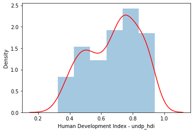

```python
sns.distplot(df['Human Development Index - undp_hdi'],kde_kws={"color": "red"})
```

the loss of feeding is index strongly on human development as shown when undernourishment increases the human development decrease

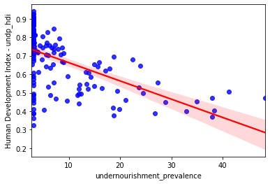

```python
sns.regplot(y='Human Development Index - undp_hdi',x='undernourishment_prevalence',data=df,scatter_kws={"color": "blue"}, line_kws={"color": "red"})
```

not as we think that the development is related to the renewablity of elecricity as there some countries there population is big and the human development is big also but they had the traditional energy

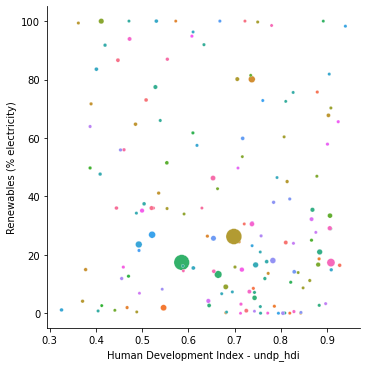

```python
sns.relplot(x='Human Development Index - undp_hdi', y='Renewables (% electricity)',legend=False,hue='country_name', size='Population', sizes=(10, 250), data=df)
```

but may be it related(renewables) to the population below poverty line

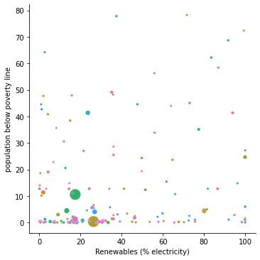

```python
sns.relplot(y='population below poverty line', x='Renewables (% electricity)',legend=False,hue='country_name', size='Population', sizes=(10, 250), data=df)
```

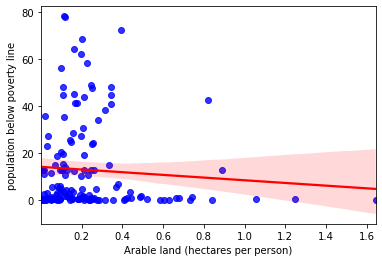

```python
sns.regplot(x='Arable land (hectares per person)',y='population below poverty line',data=df,scatter_kws={"color": "blue"}, line_kws={"color": "red"})
```

there is a bright sight as the biggest part of the world is above the poverty line

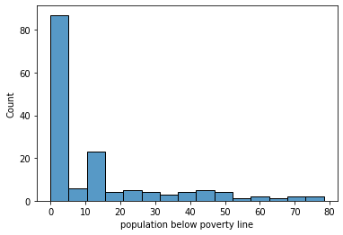

```python
sns.histplot(df['population below poverty line'],kde_kws={"color": "red"})
```

the inerested thing that the percentage of land that arable isnot effected on water withdrawal per person

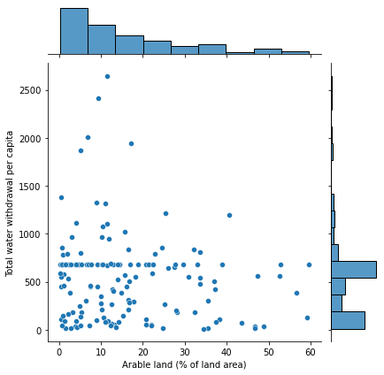

```python
sns.jointplot(df['Arable land (% of land area)'],df['Total water withdrawal per capita'])
```

there is some relations between some indicators and each other

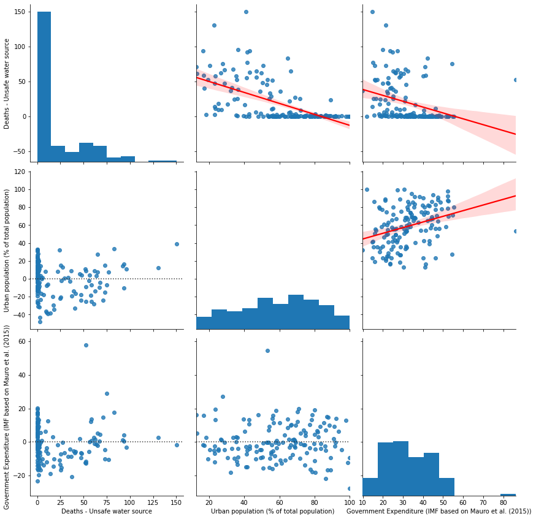

```python
g = sns.PairGrid(df[['Deaths - Unsafe water source','Urban population (% of total population)','Government Expenditure (IMF based on Mauro et al. (2015))']],size=4)
g.map_upper(sns.regplot,line_kws={"color": "red"})
g.map_lower(sns.residplot)
g.map_diag(plt.hist)
```

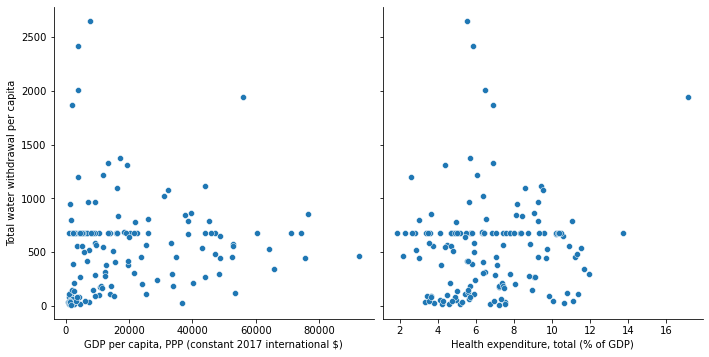

```python
g = sns.pairplot(df,
                 x_vars=['GDP per capita, PPP (constant 2017 international $)','Health expenditure, total (% of GDP)'],
                 y_vars=['Total water withdrawal per capita'],size=5)
```

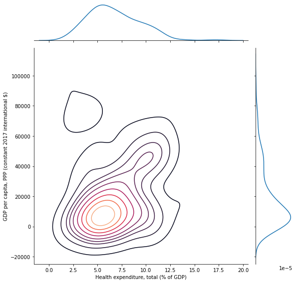

```python
sns.jointplot(x='Health expenditure, total (% of GDP)',y='GDP per capita, PPP (constant 2017 international $)',data=df,kind='kde',height=8,cmap='rocket')
```

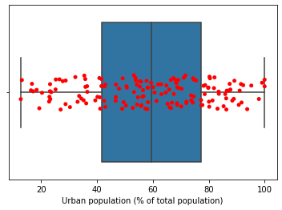

```python
sns.boxplot(df['Urban population (% of total population)'])
sns.stripplot(x='Urban population (% of total population)',color='red',data=df)
```

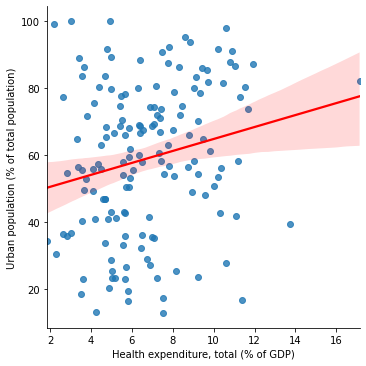

```python
sns.lmplot(x='Health expenditure, total (% of GDP)',y='Urban population (% of total population)',line_kws={"color": "red"},data=df)
```

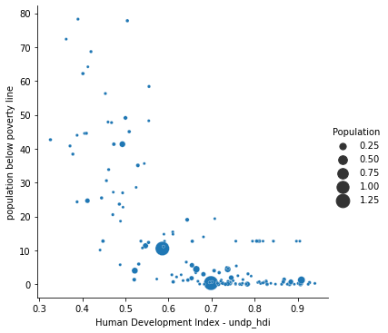

```python
sns.relplot(x='Human Development Index - undp_hdi', y='population below poverty line', size='Population', sizes=(10, 250), data=df)
```

```python
y=df['Human Development Index - undp_hdi']
x=df.drop(['country_name','country_code','Human Development Index - undp_hdi'],axis=1)
from sklearn.model_selection import train_test_split
x_train,x_test,y_train,y_test=train_test_split(x,y,test_size=0.2,random_state=45)
```